# Lesson24

```r
library(tidyverse)
```

Read the file `dataset.RDA` using readRDS

```r
dt <- readRDS(here::here('lectures', 'lesson24_reviews','dataset.RDA'))
```

Adjust the datatypes as needed. Use mutate_at to apply the same function to multiple columns

```r
dt <- dt %>% mutate(ratingDate = lubridate::mdy(ratingDate)) %>%
  mutate_at(vars(helpfulVotes, totalScore:Service), as.double)
```

Write a function called to plot a chart of rating frequencies for a single hotel. Add a title to each plot with the hotel name. Add an error message if the hotel name does not match any of the hotels in the dataset

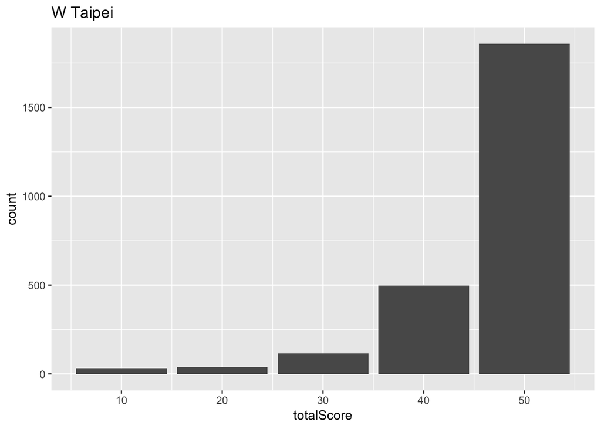

```r
ratingsHist <- function(df, name) {
  if (!(name %in% unique(df$hotel))) stop('You need to pick a hotel within those avaialble in the dataset')
  ggplot(filter(df, hotel == name)) +
    geom_bar(aes(x = totalScore)) +
    ggtitle(name)
}

ratingsHist(dt, 'W Taipei')
```

Use iteration to create a plot (using ratingHist) for 5 hotels. Save all of them separately into a folder called `figures`.

```r
#we can write an if statement to conditionally create the folder figures
if(!('figures' %in% list.dirs(here::here('lectures', 'lesson24_reviews'), full.names = F))) dir.create(here::here('lectures', 'lesson24_reviews', 'figures'))
```

```r
plots <- purrr::map(.x = unique(dt$hotel)[1:5], ~ ratingsHist(dt, .x))
purrr::map2(.x = plots, .y = unique(dt$hotel)[1:5],
            ~ ggsave(filename = paste0('figures/', .y, '.png'), plot = .x))
```

Researchers claim that over time the rating distribution changes from approximately “normal” to a J-shaped distribution (read Hu et al. 2009). Do the data support this claim? Start by plotting a hotel with a largen number of reviews to visualize how the distribution changes over time. Then repeat on multiple hotels to assess whether your finding is generalizable

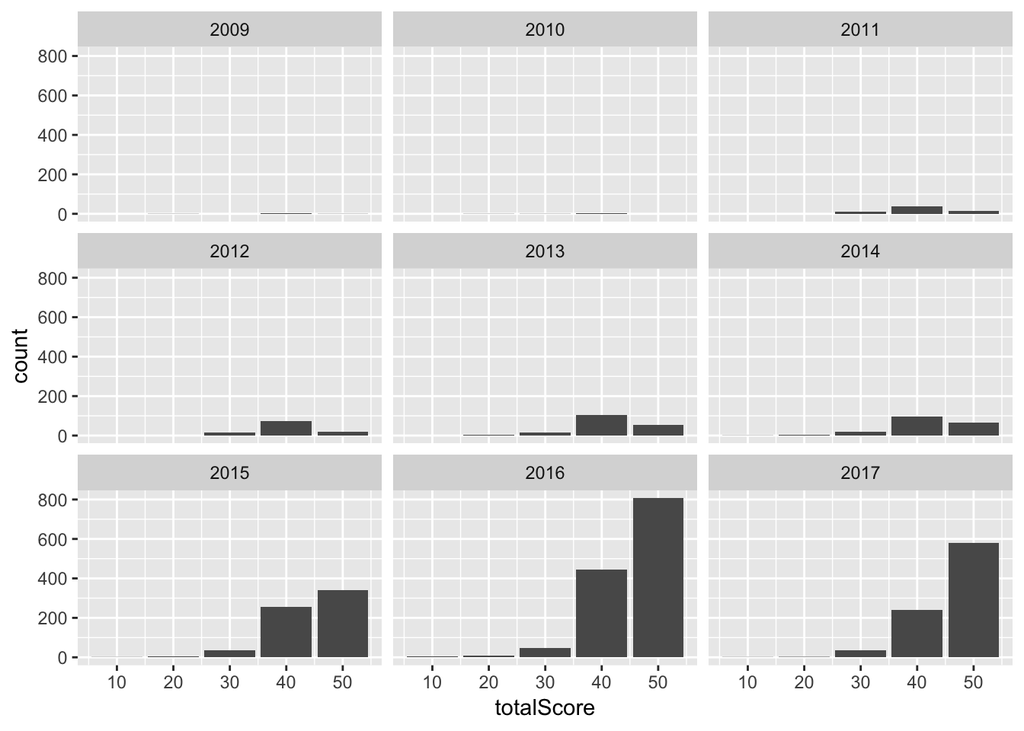

```r
dtCosmos <- dt %>% filter(hotel == 'Cosmos Hotel Taipei')

dtCosmos %>%
  ggplot() +
  geom_bar(aes(x = totalScore)) +
  facet_wrap(~ lubridate::year(ratingDate))
```

Other researchers argues that most recent reviews are more positive because of the pervasiveness of mobile phones. Is the average score of reviews from mobile higher than for others?

```r
dtCosmos %>%
  group_by(mobile) %>%
  summarise(avg = mean(totalScore, na.rm = T))
```

```
## # A tibble: 2 x 2
##   mobile       avg
##   <chr>      <dbl>
## 1 via mobile  46.2
## 2 <NA>        42.7
```

Show the trend of the cumulative mean. Use `cumsum` to calculate the cumulative mean of the scores.

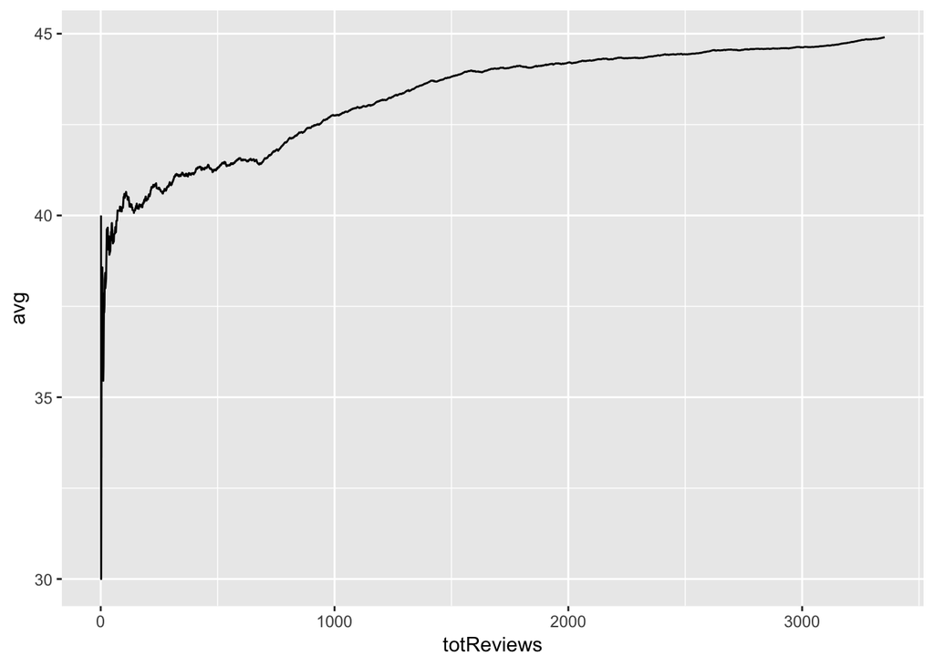

```r
dtCosmos %>%
  arrange(ratingDate) %>%
  mutate(dummy = 1, totReviews  = cumsum(dummy), sum = cumsum(totalScore)) %>%
  select(totReviews, sum) %>%
  mutate(avg = sum/totReviews) %>%
  ggplot() +
  geom_line(aes(x = totReviews, y = avg))
```

Use facetting to plot the score distributions for each attribute from Value to Service

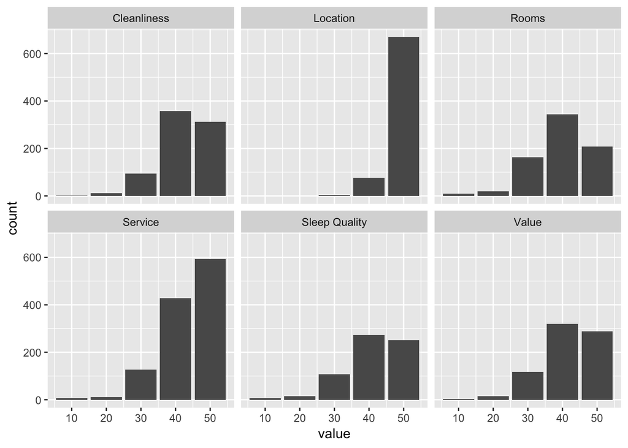

```r
dtCosmos %>% gather('attribute', 'value', Value:Service) %>%
  filter(!is.na(value)) %>%
  ggplot() +
  geom_bar(aes(x = value)) +
  facet_wrap(~ attribute)
```